# Aprendizaje supervisado: Árbol de decisión

En primer lugar se instalan los paquetes y se cargan las librerías necesarias.

```r
#install.packages("rpart")
#install.packages("rpart.plot")
#install.packages("gplots")
#install.packages("caret")
library(rpart)
library(rpart.plot)
library(dplyr)
library(caret)
```

Cargo el dataframe

```r
grafodf <- read.table("./grafodf.txt", header = TRUE, sep = ",")
```

Cambio los nombres de las columnas para facilitar la aplicación de los algoritmos.

```r
colnames(grafodf) <- c( "ID", "NODOS", "X1","X2", "X3", "X4", "Y1", "Y2" )
grafodf
```

| ID | NODOS | X1 | X2 | X3 | X4 | Y1 | Y2 |
| --- | --- | --- | --- | --- | --- | --- | --- |
| 1 | KRT19 | 0.5875 | 0.2779780360 | 0.9844992 | 0.0468462952 | 0 | 0 |
| 2 | EPCAM | 0.5500 | 0.1870034906 | 0.9860939 | 0.3733925291 | 0 | 0 |
| 3 | TACSTD2 | 0.5500 | 0.2773834463 | 0.9851365 | 0.0477648500 | 0 | 0 |
| 4 | MAL2 | 0.5500 | 0.2130654382 | 0.9857746 | 0.5451622780 | 0 | 0 |
| 5 | TGFBI | 0.9375 | 0.9767166663 | 0.9977125 | 0.0000000000 | 0 | 0 |
| 6 | AGR2 | 0.4500 | 0.1554100098 | 0.9825916 | 0.0696570729 | 0 | 0 |
| 7 | VIM | 0.4500 | 0.2146015109 | 0.9864134 | 0.1037966932 | 0 | 0 |
| 8 | GJA1 | 0.4375 | 0.4778779212 | 0.9769080 | 0.0000000000 | 0 | 0 |
| 9 | SRGN | 0.1500 | 0.0382540691 | 0.9586812 | 0.0000000000 | 0 | 0 |
| 10 | IGFBP7 | 0.5750 | 0.6494478542 | 0.9800583 | 0.0000000000 | 0 | 0 |

[output cut: 167 more lines]

Convierto las variables de respuesta en factores.

```r
grafodf$Y1 <- as.factor(grafodf$Y1)
grafodf$Y2 <- as.factor(grafodf$Y2)
```

Creo dos conjuntos, uno para cada etiqueta.

```r
df1 <- grafodf[, 3:7]
df2 <- select(grafodf,3,4,5,6, 8)
```

```r
set.seed(3456)

trainIndex1 <- createDataPartition(df1$Y1, p = .75,
                                  list = FALSE)
trainY1 <- df1[ trainIndex1,]
testY1  <- df1[-trainIndex1,]
```

```r
summary(trainY1)
```

```
       X1               X2               X3               X4
 Min.   :0.0000   Min.   :0.0000   Min.   :0.0000   Min.   :0.00000
 1st Qu.:0.1187   1st Qu.:0.0653   1st Qu.:0.9607   1st Qu.:0.00000
 Median :0.4500   Median :0.2591   Median :0.9788   Median :0.00000
 Mean   :0.4138   Mean   :0.3671   Mean   :0.8751   Mean   :0.04042
 3rd Qu.:0.6375   3rd Qu.:0.6573   3rd Qu.:0.9867   3rd Qu.:0.02342
 Max.   :0.9625   Max.   :0.9920   Max.   :0.9984   Max.   :0.94412
 Y1
 0:120
 1: 14
```

```r
dim(trainY1)
```

```
[1] 134   5
```

```r
summary(testY1)
```

```
       X1               X2                X3               X4
 Min.   :0.0000   Min.   :0.00000   Min.   :0.0000   Min.   :0.00000
 1st Qu.:0.1125   1st Qu.:0.06203   1st Qu.:0.9591   1st Qu.:0.00000
 Median :0.4125   Median :0.21205   Median :0.9804   Median :0.00000
 Mean   :0.4587   Mean   :0.40936   Mean   :0.8861   Mean   :0.08956
 3rd Qu.:0.8000   3rd Qu.:0.84298   3rd Qu.:0.9935   3rd Qu.:0.01592
 Max.   :1.0000   Max.   :1.00000   Max.   :1.0000   Max.   :1.00000
 Y1
 0:39
 1: 4
```

```r
dim(testY1)
```

```
[1] 43  5
```

Comprobamos que las etiquetas siguen una distribución similar al conjunto completo.

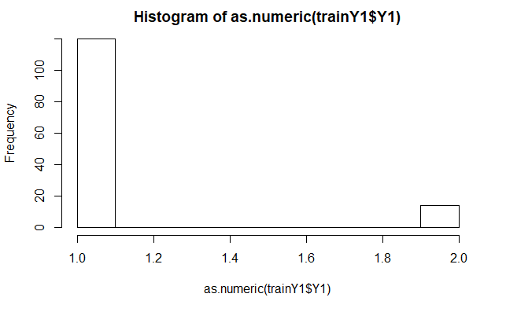

```r
hist(as.numeric(trainY1$Y1))
```

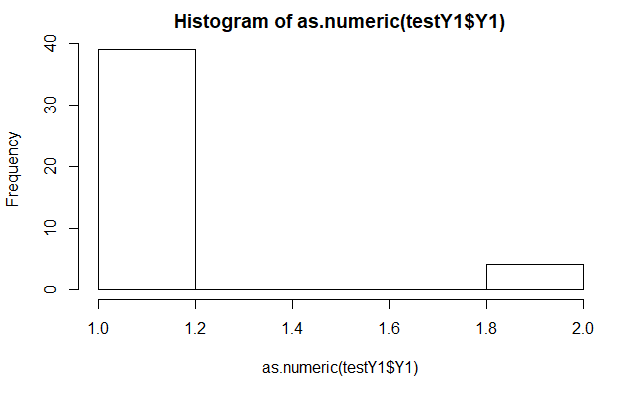

```r
hist(as.numeric(testY1$Y1))
```

- Y2.

```r
set.seed(1)
trainIndex2 <- createDataPartition(df2$Y2, p = .75,
                                  list = FALSE)
trainY2 <- df2[ trainIndex2,]
testY2  <- df2[-trainIndex2,]
```

Visualizamos los conjuntos. El conjunto de train está formado por 133 ejemplos y el de test, por 44.

```r
summary(trainY2)
```

```
       X1               X2                X3               X4
 Min.   :0.0000   Min.   :0.00000   Min.   :0.0000   Min.   :0.00000
 1st Qu.:0.1500   1st Qu.:0.09649   1st Qu.:0.9642   1st Qu.:0.00000
 Median :0.4875   Median :0.28297   Median :0.9813   Median :0.00000
 Mean   :0.4477   Mean   :0.40083   Mean   :0.8829   Mean   :0.05215
 3rd Qu.:0.7125   3rd Qu.:0.73472   3rd Qu.:0.9903   3rd Qu.:0.02373
 Max.   :1.0000   Max.   :1.00000   Max.   :1.0000   Max.   :1.00000
 Y2
 0:117
 1: 16
```

```r
dim(trainY2)
```

```
[1] 133   5
```

```r
summary(testY2)
```

```
       X1                X2                X3               X4
 Min.   :0.00000   Min.   :0.00000   Min.   :0.0000   Min.   :0.0000000
 1st Qu.:0.05937   1st Qu.:0.02743   1st Qu.:0.9526   1st Qu.:0.0000000
 Median :0.33125   Median :0.16716   Median :0.9724   Median :0.0000000
 Mean   :0.35511   Mean   :0.30657   Mean   :0.8623   Mean   :0.0530030
 3rd Qu.:0.54063   3rd Qu.:0.49819   3rd Qu.:0.9840   3rd Qu.:0.0000383
 Max.   :0.96250   Max.   :0.97672   Max.   :0.9987   Max.   :0.9441212
 Y2
 0:39
 1: 5
```

```r
dim(testY2)
```

```
[1] 44  5
```

Comprobamos que las etiquetas siguen una distribución similar al conjunto completo.

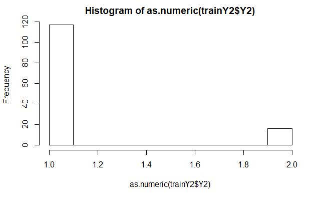

```r
hist(as.numeric(trainY2$Y2))
```

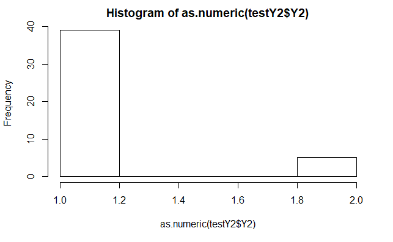

```r
hist(as.numeric(testY2$Y2))
```

Se construyen los modelos básicos, con los ajustes por defecto. El árbol para Y1 es muy sencillo, con un solo nodo. El árbol para Y2 es un poco más complejo.

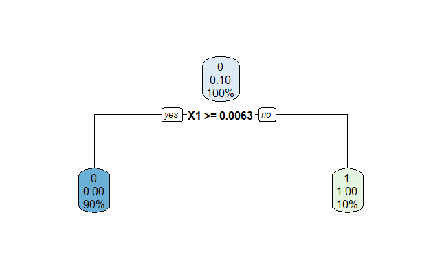

```r
fit1 <- rpart(Y1~., data = trainY1, method = 'class')
rpart.plot(fit1)
```

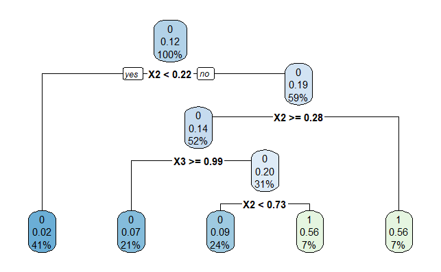

```r
fit2 <- rpart(Y2~., data = trainY2, method = 'class')
rpart.plot(fit2)
```

Observamos la construcción de los árboles. El primero:

```r
summary(fit1)
```

```
Call:
rpart(formula = Y1 ~ ., data = trainY1, method = "class")
  n= 134

    CP nsplit rel error xerror      xstd
1 1.00      0         1      1 0.2529148
2 0.01      1         0      0 0.0000000

Variable importance
X1 X2 X3
33 33 33

Node number 1: 134 observations,    complexity param=1
  predicted class=0  expected loss=0.1044776  P(node) =1
    class counts:   120    14
   probabilities: 0.896 0.104
  left son=2 (120 obs) right son=3 (14 obs)
  Primary splits:
      X1 < 0.00625      to the right, improve=25.074630, (0 missing)
      X2 < 0.0001559664 to the right, improve=25.074630, (0 missing)
      X3 < 0.4524876    to the right, improve=25.074630, (0 missing)
      X4 < 7.654623e-05 to the right, improve= 1.529172, (0 missing)
  Surrogate splits:
      X2 < 0.0001559664 to the right, agree=1, adj=1, (0 split)
      X3 < 0.4524876    to the right, agree=1, adj=1, (0 split)

Node number 2: 120 observations
  predicted class=0  expected loss=0  P(node) =0.8955224
    class counts:   120     0
   probabilities: 1.000 0.000

Node number 3: 14 observations
  predicted class=1  expected loss=0  P(node) =0.1044776
    class counts:     0    14
   probabilities: 0.000 1.000
```

El segundo:

```r
summary(fit2)
```

```
Call:
rpart(formula = Y2 ~ ., data = trainY2, method = "class")
  n= 133

       CP nsplit rel error xerror      xstd
1 0.03125      0     1.000    1.0 0.2344807
2 0.01000      4     0.875    1.5 0.2771871

Variable importance
X2 X1 X3 X4
50 26 23  1

Node number 1: 133 observations,    complexity param=0.03125
  predicted class=0  expected loss=0.1203008  P(node) =1
    class counts:   117    16
   probabilities: 0.880 0.120
  left son=2 (55 obs) right son=3 (78 obs)
  Primary splits:
      X2 < 0.2168581    to the left,  improve=1.9559700, (0 missing)
      X1 < 0.25625      to the left,  improve=1.0904610, (0 missing)
      X3 < 0.9592892    to the left,  improve=1.0265660, (0 missing)
      X4 < 0.0818662    to the right, improve=0.3817809, (0 missing)
  Surrogate splits:
      X1 < 0.25625      to the left,  agree=0.865, adj=0.673, (0 split)
      X3 < 0.9660229    to the left,  agree=0.865, adj=0.673, (0 split)

Node number 2: 55 observations
  predicted class=0  expected loss=0.01818182  P(node) =0.4135338
    class counts:    54     1
   probabilities: 0.982 0.018

Node number 3: 78 observations,    complexity param=0.03125
  predicted class=0  expected loss=0.1923077  P(node) =0.5864662
    class counts:    63    15
   probabilities: 0.808 0.192
  left son=6 (69 obs) right son=7 (9 obs)
  Primary splits:
      X2 < 0.2759068    to the right, improve=2.6848760, (0 missing)
      X1 < 0.49375      to the right, improve=1.8085470, (0 missing)
      X3 < 0.9848178    to the right, improve=1.6425340, (0 missing)
```

[output cut: 38 more lines]

```
      X3 < 0.988976     to the left,  improve=0.9200656, (0 missing)
      X4 < 0.0004592774 to the left,  improve=0.1810791, (0 missing)
  Surrogate splits:
      X1 < 0.64375      to the left,  agree=0.878, adj=0.444, (0 split)
      X3 < 0.987533     to the left,  agree=0.829, adj=0.222, (0 split)

Node number 26: 32 observations
  predicted class=0  expected loss=0.09375  P(node) =0.2406015
    class counts:    29     3
   probabilities: 0.906 0.094

Node number 27: 9 observations
  predicted class=1  expected loss=0.4444444  P(node) =0.06766917
    class counts:     4     5
   probabilities: 0.444 0.556
```

Mostramos estadísticas del proceso de construcción de cada árbol.

```r
printcp(fit1)
```

```
Classification tree:
rpart(formula = Y1 ~ ., data = trainY1, method = "class")

Variables actually used in tree construction:
[1] X1

Root node error: 14/134 = 0.10448

n= 134

    CP nsplit rel error xerror    xstd
1 1.00      0         1      1 0.25291
2 0.01      1         0      0 0.00000
```

```r
printcp(fit2)
```

```
Classification tree:
rpart(formula = Y2 ~ ., data = trainY2, method = "class")

Variables actually used in tree construction:
[1] X2 X3

Root node error: 16/133 = 0.1203

n= 133

       CP nsplit rel error xerror    xstd
1 0.03125      0     1.000    1.0 0.23448
2 0.01000      4     0.875    1.5 0.27719
```

Predecimos y evaluamos el desempeño de los modelos.

- Etiqueta Y1 (ser nodo aislado): La precisión es 1. Todos los ejemplos se clasifican correctamente, no hay error.

```r
pred1 <- predict(fit1, testY1, type = 'class')
confusionMatrix(table(pred1, testY1$Y1))
```

```
Confusion Matrix and Statistics


pred1  0  1
    0 39  0
    1  0  4

               Accuracy : 1
                 95% CI : (0.9178, 1)
    No Information Rate : 0.907
    P-Value [Acc > NIR] : 0.01502

                  Kappa : 1

 Mcnemar's Test P-Value : NA

            Sensitivity : 1.000
            Specificity : 1.000
         Pos Pred Value : 1.000
         Neg Pred Value : 1.000
             Prevalence : 0.907
         Detection Rate : 0.907
   Detection Prevalence : 0.907
      Balanced Accuracy : 1.000

       'Positive' Class : 0
```

```r
pred2 <- predict(fit2, testY2, type = 'class')
confusionMatrix(table(pred2, testY2$Y2))
```

```
Confusion Matrix and Statistics


pred2  0  1
    0 37  3
    1  2  2

               Accuracy : 0.8864
                 95% CI : (0.7544, 0.9621)
    No Information Rate : 0.8864
    P-Value [Acc > NIR] : 0.6162

                  Kappa : 0.382

 Mcnemar's Test P-Value : 1.0000

            Sensitivity : 0.9487
            Specificity : 0.4000
         Pos Pred Value : 0.9250
         Neg Pred Value : 0.5000
             Prevalence : 0.8864
         Detection Rate : 0.8409
   Detection Prevalence : 0.9091
      Balanced Accuracy : 0.6744

       'Positive' Class : 0
```

Estos datos, sin embargo, proceden de un único proceso de entrenamiento y validación de los modelos. Ahora se hace uso de validación cruzada, con la que se entrena y prueba varias veces el modelo, obteniéndose múltiples estimaciones de error. Si las estimaciones son similares, el modelo será bueno. Se utiliza K-CV, con k =10.

```r
control_class <- trainControl(
  method = "cv",
  number = 10
)
```

También optimizamos los hiperparámetros del Árbol de decisión, probando distintos valores y evaluándolos con validación cruzada.

El modelo que predice sobre la clase Y1 no puede mejorar puesto que la precisión es 1. Estos datos, además de la estructura del árbol construido, nos llevan a pensar que la clase en la que se basa la clasificación no es buena. Por ello, no seguiremos haciendo mejoras para los datos con Y1.

```r
cps = seq(0 , 1, by=0.05)
arbol2 <- train (Y2 ~ ., trainY2,
                 tuneGrid = expand.grid(cp = cps),
                 method="rpart",
                 trControl=control_class)
print(arbol2)
```

```
CART

133 samples
  4 predictor
  2 classes: '0', '1'

No pre-processing
Resampling: Cross-Validated (10 fold)
Summary of sample sizes: 119, 119, 121, 120, 119, 119, ...
Resampling results across tuning parameters:

  cp    Accuracy   Kappa
  0.00  0.8133700  -0.004072485
  0.05  0.8597070  -0.027192982
  0.10  0.8668498  -0.016666667
  0.15  0.8811355   0.000000000
  0.20  0.8811355   0.000000000
  0.25  0.8811355   0.000000000
  0.30  0.8811355   0.000000000
  0.35  0.8811355   0.000000000
  0.40  0.8811355   0.000000000
  0.45  0.8811355   0.000000000
  0.50  0.8811355   0.000000000
  0.55  0.8811355   0.000000000
  0.60  0.8811355   0.000000000
  0.65  0.8811355   0.000000000
  0.70  0.8811355   0.000000000
  0.75  0.8811355   0.000000000
  0.80  0.8811355   0.000000000
  0.85  0.8811355   0.000000000
  0.90  0.8811355   0.000000000
  0.95  0.8811355   0.000000000
  1.00  0.8811355   0.000000000

Accuracy was used to select the optimal model using the largest value.
The final value used for the model was cp = 1.
```

Predecimos usando el modelo óptimo:

```r
pred2 <- predict(arbol2, testY2)
confusionMatrix(table(pred2, testY2$Y2))
```

```
Confusion Matrix and Statistics


pred2  0  1
    0 39  5
    1  0  0

               Accuracy : 0.8864
                 95% CI : (0.7544, 0.9621)
    No Information Rate : 0.8864
    P-Value [Acc > NIR] : 0.61617

                  Kappa : 0

 Mcnemar's Test P-Value : 0.07364

            Sensitivity : 1.0000
            Specificity : 0.0000
         Pos Pred Value : 0.8864
         Neg Pred Value :    NaN
             Prevalence : 0.8864
         Detection Rate : 0.8864
   Detection Prevalence : 1.0000
      Balanced Accuracy : 0.5000

       'Positive' Class : 0
```

El accuracy es el mismo y el árbol ha perdido calidad (clasifica todo como la clase dominante, 0). La métrica Kappa también denota esto, siendo 0. En este caso, la optimización no ha mejorado el modelo.